# Servidores classificados por gênero

Poder Executivo

09 março 2023

## Sumário Executivo

Segundo o disposto na Convenção nº 111 da Organização Internacional do Trabalho (OIT), toda distinção, exclusão ou preferência fundada na raça, cor, sexo, religião, opinião política, ascendência nacional ou origem social que tenha por efeito destruir ou alterar a igualdade em matéria de emprego ou profissão é ato discriminatório. Não sendo consideradas discriminatórias, no entanto, as distinções, exclusões ou preferências fundadas em qualificações exigidas para um determinado emprego.

Alcançar a igualdade de gênero não é um processo de curto prazo. Exige grande vontade política e um esforço conjunto por parte de governos, sociedade civil, organismos internacionais e outros, porém as reformas legais e regulatórias podem ter um papel fundamental e ser um importante primeiro passo, conforme disposto em artigo do Banco Mundial. Ainda no mesmo artigo, a Presidente interina do Grupo Banco Mundial, Kristalina Georgieva, salienta que os avanços vêm ocorrendo, mas não em um ritmo rápido o suficiente, e 2,7 bilhões de mulheres ainda enfrentam impedimentos legais no acesso às mesmas oportunidades de emprego que os homens e que é primordial que essas barreiras sejam eliminadas.

A Constituição Federal (CF) buscando promover a igualdade entre homens e mulheres dispõe que constituem objetivos fundamentais da República Federativa do Brasil: promover o bem de todos, sem preconceitos de origem, raça, **sexo**, cor, idade e quaisquer outras formas de discriminação (inciso IV do artigo 3º). Cabe mencionar ainda que em seu artigo 5º a Constituição menciona que todos são iguais perante a Lei, sem distinção de qualquer natureza, sendo homens e mulheres iguais em direitos e obrigações (inciso I).

A seguir, cabe mencionar ainda o disposto no artigo 7º da CF que assim dispõe:

> “Art. 7º São direitos dos trabalhadores urbanos e rurais, além de outros que visem à melhoria de sua condição social: (…)

> XXX - proibição de diferença de salários, de exercício de funções e de critério de admissão por motivo de sexo, idade, cor ou estado civil;” (Grifo nosso)

Tais dispositivos não deixam dúvidas quanto à importância que é dada ao princípio da Igualdade, sendo considerado como um dos pilares do Estado Democrático de Direito, que busca repelir a discriminação e o tratamento desigual entre os cidadãos. A Constituição ratifica esse princípio por meio de várias normas, algumas diretamente determinadoras da igualdade, outras buscando a equidade entre os desiguais mediante a concessão de direitos sociais fundamentais.

## Dados

**Servidores ativos classificados por sexo**

No serviço público, a ocupação de cargos no serviço público por mulheres têm se mantido estável ao longo do tempo. A seguir, podemos observar o quantitativo de servidores ativos separados por sexo no Poder Executivo Federal Civil.

| ano | mulheres | homens | total_ativos | percent_mulheres | percent_homens |
| --- | --- | --- | --- | --- | --- |
| 2010 | 258.174 | 322.178 | 580.352 | 44,5% | 55,5% |
| 2011 | 261.352 | 323.767 | 585.119 | 44,7% | 55,3% |
| 2012 | 264.678 | 326.165 | 590.843 | 44,8% | 55,2% |
| 2013 | 271.661 | 331.034 | 602.695 | 45,1% | 54,9% |
| 2014 | 282.372 | 341.723 | 624.095 | 45,2% | 54,8% |
| 2015 | 285.186 | 342.241 | 627.427 | 45,5% | 54,5% |
| 2016 | 288.289 | 344.196 | 632.485 | 45,6% | 54,4% |
| 2017 | 289.675 | 344.482 | 634.157 | 45,7% | 54,3% |
| 2018 | 289.388 | 341.301 | 630.689 | 45,9% | 54,1% |
| 2019 | 278.395 | 329.438 | 607.833 | 45,8% | 54,2% |
| 2020 | 273.748 | 326.104 | 599.852 | 45,6% | 54,4% |
| 2021 | 264.387 | 319.287 | 583.674 | 45,3% | 54,7% |
| 2022 | 253.264 | 311.735 | 564.999 | 44,8% | 55,2% |

Com base nos dados do gráfico, podemos observar um índice médio em torno de 45,3% em relação ao quantitativo de mulheres ocupantes de cargos no serviço público, enquanto o percentual de homens gira em torno de 54,6% da força de trabalho total. No período de 2010 a 2018, o percentual de mulheres cresceu pouco, totalizando um aumento de 1,4%, tendo ocorrido uma queda nos anos de 2019, 2020, 2021 e 2022 de 1,1% em relação ao ano de 2018.

[interactive chart not shown]

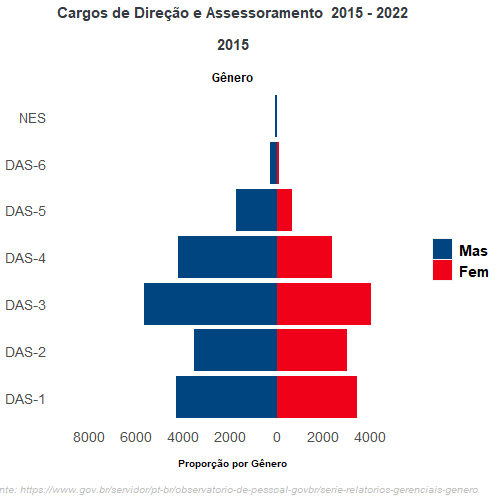

| Unidade da Federação | Feminino | Masculino | Total | % Feminino | % Masculino |
| --- | --- | --- | --- | --- | --- |
| Acre | 1,468 | 2,351 | 3,819 | 38.4% | 61.6% |
| Alagoas | 3,408 | 4,431 | 7,839 | 43.5% | 56.5% |
| Amazonas | 3,948 | 5,768 | 9,716 | 40.6% | 59.4% |
| Amapá | 5,156 | 4,775 | 9,931 | 51.9% | 48.1% |
| Bahia | 10,174 | 13,329 | 23,503 | 43.3% | 56.7% |
| Ceará | 7,342 | 10,462 | 17,804 | 41.2% | 58.8% |
| Distrito Federal | 34,246 | 43,463 | 77,709 | 44.1% | 55.9% |
| Espírito Santo | 4,161 | 6,081 | 10,242 | 40.6% | 59.4% |
| Goiás | 6,141 | 7,377 | 13,518 | 45.4% | 54.6% |
| Maranhão | 4,864 | 6,974 | 11,838 | 41.1% | 58.9% |
| Minas Gerais | 23,517 | 28,406 | 51,923 | 45.3% | 54.7% |
| Mato Grosso do Sul | 4,164 | 6,106 | 10,270 | 40.5% | 59.5% |
| Mato Grosso | 3,715 | 5,108 | 8,823 | 42.1% | 57.9% |
| Pará | 7,613 | 10,871 | 18,484 | 41.2% | 58.8% |
| Paraíba | 6,680 | 8,564 | 15,244 | 43.8% | 56.2% |
| Pernambuco | 9,598 | 12,624 | 22,213 | 43.2% | 56.8% |
| Piauí | 3,551 | 5,205 | 8,756 | 40.6% | 59.4% |
| Paraná | 9,536 | 12,534 | 22,070 | 43.2% | 56.8% |
| Rio de Janeiro | 44,645 | 44,698 | 89,343 | 50.0% | 50.0% |
| Rio Grande do Norte | 5,537 | 8,191 | 13,728 | 40.3% | 59.7% |
| Rondônia | 5,314 | 6,057 | 11,371 | 46.7% | 53.3% |
| Roraima | 3,705 | 3,570 | 7,275 | 50.9% | 49.1% |
| Rio Grande do Sul | 15,793 | 17,410 | 33,203 | 47.6% | 52.4% |
| Santa Catarina | 7,522 | 9,625 | 17,147 | 43.9% | 56.1% |
| Sergipe | 2,818 | 3,651 | 6,469 | 43.6% | 56.4% |
| São Paulo | 16,579 | 21,167 | 37,746 | 43.9% | 56.1% |
| Tocantins | 2,078 | 2,937 | 5,015 | 41.4% | 58.6% |

## Servidores ocupantes de cargos e funções

O governo federal publicou a Lei nº 14.204, de 16 de setembro de 2021, que simplificou a gestão de cargos e de funções de confiança na Administração Pública Federal, dispondo sobre a instituição dos Cargos Comissionados Executivos (CCE) e as Funções Comissionadas Executivas (FCE); a autorização para o Poder Executivo transformar, sem aumento de despesa, cargos em comissão, funções de confiança e gratificações; e a simplificação da gestão de cargos em comissão e de funções de confiança. Posteriormente, foi publicado o Decreto nº 10.829, de 5 de outubro de 2021, por meio do qual a Lei nº 14.204/21 foi regulamentada.

Cabe mencionar ainda o Anexo III da Lei nº 14.204/2021 que menciona que os cargos em comissão do Grupo-Direção e Assessoramento Superiores (DAS) existentes na legislação passam a referir-se também aos CCE e às FCE, conforme disposto a seguir.

| DAS | CCE | FCE |
| --- | --- | --- |
| DAS-1 | CCE-5 | FCE-5 |
| DAS-2 | CCE-7 | FCE-7 |
| DAS-3 | CCE-10 | FCE-10 |
| DAS-4 | CCE-13 | FCE-13 |
| DAS-5 | CCE-15 | FCE-15 |
| DAS-6 | CCE-17 | FCE-17 |
| NE | CCE-18 | - |

Em seguida, vamos observar a disposição dos ocupantes de cargos e funções com características de Direção e Assessoramento divididos por sexo. Cabe salientar que fazem parte desse conjunto de dados os cargos de Direção e Assessoramento Superiores (DAS), Funções Comissionadas do Poder Executivo (FCPE), cargos e funções específicos das Agências Reguladoras, cargos de direção específicos das Universidades Federais e dos Institutos do Ensino Básico, Técnico e Tecnológico Federais, Natureza especial, dentre outros.

| Ano | Mulheres | Homens | Total | % Mulheres | % Homens |
| --- | --- | --- | --- | --- | --- |
| 2010 | 13.082 | 19.218 | 32.300 | 40,5% | 59,5% |
| 2011 | 13.255 | 19.627 | 32.882 | 40,3% | 59,7% |
| 2012 | 13.648 | 20.103 | 33.751 | 40,4% | 59,6% |
| 2013 | 13.992 | 20.679 | 34.671 | 40,4% | 59,6% |
| 2014 | 14.468 | 21.298 | 35.766 | 40,5% | 59,5% |
| 2015 | 14.114 | 21.331 | 35.445 | 39,8% | 60,2% |
| 2016 | 13.021 | 20.609 | 33.630 | 38,7% | 61,3% |
| 2017 | 12.915 | 20.845 | 33.760 | 38,3% | 61,7% |
| 2018 | 12.916 | 20.326 | 33.242 | 38,9% | 61,1% |
| 2019 | 12.300 | 20.070 | 32.370 | 38,0% | 62,0% |
| 2020 | 12.353 | 20.576 | 32.929 | 37,5% | 62,5% |
| 2021 | 12.942 | 20.690 | 33.632 | 38,5% | 61,5% |

É possível observar que o índice médio de ocupação de mulheres girou em torno de 39,3% entre os anos de 2010 e 2021, enquanto o percentual de homens foi de 60,6%.

[output not shown]

Em seguida, vamos desmembrar os dados mencionados no quadro acima, relacionados, apenas, aos cargos de DAS quanto à ocupação separada por níveis e por sexo.

| Ano | Sexo | DAS-1 | DAS-2 | DAS-3 | DAS-4 | DAS-5 | DAS-6 | Total |
| --- | --- | --- | --- | --- | --- | --- | --- | --- |
| 2016 | Feminino | 42,9% | 45,3% | 46,4% | 35,1% | 22,5% | 18,6% | 41,6% |
| 2016 | Masculino | 57,1% | 54,7% | 53,6% | 64,9% | 77,5% | 81,4% | 58,4% |
| 2017 | Feminino | 46,2% | 50,0% | 48,6% | 36,8% | 23,3% | 17,6% | 43,0% |
| 2017 | Masculino | 53,8% | 50,0% | 51,4% | 63,2% | 76,7% | 82,4% | 57,0% |
| 2018 | Feminino | 46,2% | 49,8% | 48,1% | 38,5% | 25,8% | 20,4% | 43,4% |
| 2018 | Masculino | 53,8% | 50,2% | 51,9% | 61,5% | 74,2% | 79,6% | 56,6% |
| 2019 | Feminino | 44,2% | 48,4% | 48,1% | 39,6% | 25,8% | 20,3% | 42,6% |
| 2019 | Masculino | 55,8% | 51,6% | 51,9% | 60,4% | 74,2% | 79,7% | 57,4% |
| 2020 | Feminino | 43,1% | 50,2% | 49,0% | 39,1% | 25,6% | 19,8% | 42,7% |
| 2020 | Masculino | 56,9% | 49,8% | 51,0% | 60,9% | 74,4% | 80,2% | 57,3% |
| 2021 | Feminino | 43,2% | 51,8% | 50,3% | 40,0% | 27,8% | 22,4% | 43,8% |
| 2021 | Masculino | 56,8% | 48,2% | 49,7% | 60,0% | 72,2% | 77,6% | 56,2% |

Os DAS estão estratificados em seis níveis, sendo o nível 6 o mais alto, ocupado por secretários nacionais e diretores ou presidentes de autarquias e fundações. Cargos de confiança no setor público são posições de liderança. Do total de DAS disponibilizados em 2021, as mulheres ocupavam 43,8%. O quantitativo de ocupação por mulheres é equivalente ao quantitativo de homens até o nível 3, quando ocupavam 50,3% das posições, enquanto o percentual de homens era de 49,7% no ano de 2021. Porém, a partir do nível 4, vê-se uma diminuição na participação das mulheres nos cargos de confiança. Note-se que no nível 6, apenas 22,4% dos cargos são ocupados pelo sexo feminino, sendo o total de homens de 77,6%. De acordo com o Gráfico nº 5, observa-se que essa situação não é uma característica de um ponto específico no tempo, sendo uma configuração que se apresenta de forma consistente ao longo dos anos.

Vamos observar ainda a disposição dos ocupantes de Funções e Gratificações Técnicas divididos por sexo. Cabe mencionar que fazem parte desse conjunto de dados as Funções Gratificadas (FG) dos Ministérios, Autarquias e Fundações, FG das Universidades e Institutos Federais, Funções e Gratificações específicos das Agências Reguladoras, entre outros.

| Ano | Mulheres | Homens | Total | % Mulheres | % Homens | % Total |
| --- | --- | --- | --- | --- | --- | --- |
| 2010 | 25089 | 30.187 | 55.276 | 45,4% | 54,6% | 100% |
| 2011 | 25.249 | 30.184 | 55.433 | 45,5% | 54,5% | 100% |
| 2012 | 26.395 | 31698 | 58.093 | 45,4% | 54,6% | 100% |
| 2013 | 27.851 | 34.279 | 62.130 | 44,8% | 55,2% | 100% |
| 2014 | 29.079 | 36.119 | 65.198 | 44,6% | 55,4% | 100% |
| 2015 | 29.442 | 37.039 | 66.481 | 44,3% | 55,7% | 100% |
| 2016 | 29.308 | 37.379 | 66.687 | 43,9% | 56,1% | 100% |
| 2017 | 28.843 | 37.950 | 66.793 | 43,2% | 56,8% | 100% |
| 2018 | 28.770 | 37.821 | 66.591 | 43,2% | 56,8% | 100% |
| 2019 | 22.926 | 32.796 | 55.722 | 41,1% | 58,9% | 100% |
| 2020 | 23.706 | 33.584 | 57.290 | 41,4% | 58,6% | 100% |
| 2021 | 23.108 | 33.039 | 56.147 | 41,2% | 58,8% | 100% |

Quanto à ocupação de Funções e Gratificações Técnicas, é possível observar um índice médio de ocupação pelas mulheres entre o ano de 2010 e 2021 em torno de 43,6%; enquanto o de homens foi em torno de 56,3%.

## Fontes e metodologia Base de Dados

A fonte primária para a obtenção das informações apresentadas é o Sistema Integrado de Administração de Pessoal (SIAPE) e o Painel Estatístico de Pessoal (PEP), no [**link**](http://painel.pep.planejamento.gov.br)

Outras fontes:

[**Convenção OIT**](http://www.planalto.gov.br/ccivil_03/_Ato2019-2022/2019/Decreto/D10088.htm#art5)

[**Banco Mundial**](https://www.worldbank.org/pt/news/press-release/2019/02/27/despite-gains-women-face-setbacks-in-legal-rights-affecting-work)

[**Constituição Federal**](http://www.planalto.gov.br/ccivil_03/constituicao/constituicao.htm)

## Revisões

A revisões são realizadas anualmente, conforme necessário, como resultado de atualização de base de dados.

## Institucional

Eduardo Bergamaschi Felizola - Secretário

Antônio Fuiza de Sousa Landim – Diretor

Mirian Lucia Bittencourt Guimarães – Coordenadora-Geral

Equipe técnica

- Luana Correa Silva Rodrigues

## Contato

Coordenação-Geral de Informações Gerenciais – CGINF

Departamento de Soluções Digitais e Informações Gerenciais – Ministério da Economia

Esplanada dos Ministério, Bloco C, 9º andar, sala 940

70297-400 – Brasília/DF

Tel: (61) 2020-1179 E-mail: sgp.cginf@economia.gov.br

## Origem Étnica

[interactive chart not shown]

## PCD

[interactive chart not shown]

## Estado Civil

[interactive chart not shown]

## Escolaridade

Talvez criar uma categoria outras e renomear

[interactive chart not shown]

## Alternativa de treemap

[interactive chart not shown]

## Quantidade de Filhos

[interactive chart not shown]

## Idade

[interactive chart not shown]

## Remuneração

[interactive chart not shown]